# **Econométrie Projet Température**

GUILBERT- -ARRUGA Léo et JEBALI Ibtissem, Master 1 Big Data

Décembre 2023

# **Présentation de l’étude**

Notre étude sur les températures climatiques porte sur les villes de Barcelone et de Grenade, respectivement situées en Catalogne au nord-est de l’Espagne et au sud du pays, en Andalousie. Les données de la ville de Grenade sont peu fournies et seule la variable TAVG est utilisable, contrairement à celles de Barcelone car il manque des données observées.

De fait, nous concentrerons notre étude sur Barcelone puis comparer ces deux villes sur la période de Juin 2021 à Avril 2022. La période de Juin 2021 à Avril 2022 a été choisi car elle offre les données les plus complètes afin de comparer ces deux villes sur environ un an.

Les données sont converties en degrés Celcius afin de simplifier la lecture des représentations graphiques et les interprétations. Nous allons étudier les variations de températures quotidiennes et mensuelles pour la ville de Barcelone sur la période de Janvier 2008 à Juin 2023.

# **Définition de TAVG et DTR**

Dans le cadre de notre étude, le TAVG représente la température moyenne quotidienne ou mensuelle selon le cas. Elle est calculée en faisant la moyenne entre les températures maximales et minimales de la période voulue. Le DTR mesure l’amplitude de température de la période déterminée. Cela représente l’écart entre la température la plus faible et la plus élevée. Nous allons créer une nouvelle base de données permettant de compiler les données par mois de la ville de Barcelone afin de faciliter la lecture graphique.

# **Températures quotidiennes à Barcelone**

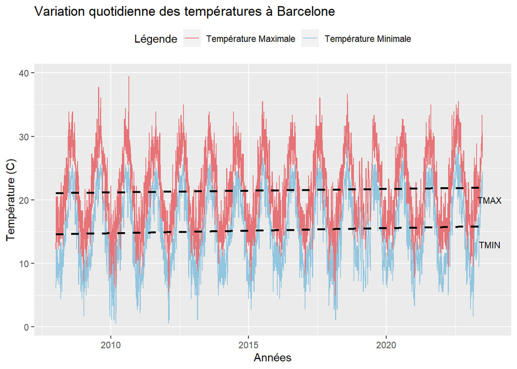

Sur le graphique ci-dessus sont representées les données de températures quotidiennes minimales et maximales de 2008 à 2023 à Barcelone. Nous remarquons que globalement toutes les années suivent la même tendance (courbes pointillées noires TMAX et TMIN). Ces lignes de tendances affichent des pentes moyennes légèrement positives, ce qui nous montre une hausse de la température au fil du temps et par conséquent un réchauffement climatique.

# **Températures mensuelles à Barcelone**

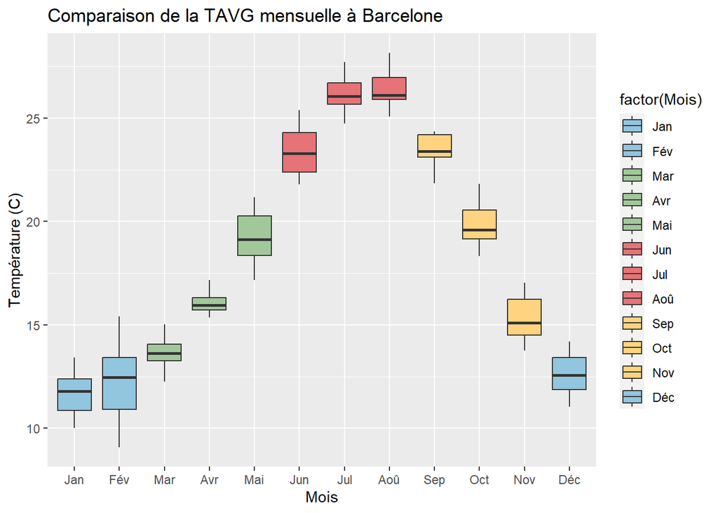

Ce graphique décrit par des boîtes à moustaches les températures moyennes mensuelles (TAVG) de la ville de Barcelone. Un code couleur par saison a été mis en place (hiver, printemps, été, automne). Nous constatons que certains mois varient très peu au fil des années. D’autres subissent des variations significatives comme les mois de Mai, Juin, Novembre et la totalité de la saison hivernale. Le mois de février est le mois avec le plus de variations selon les années, il est relativement instable.

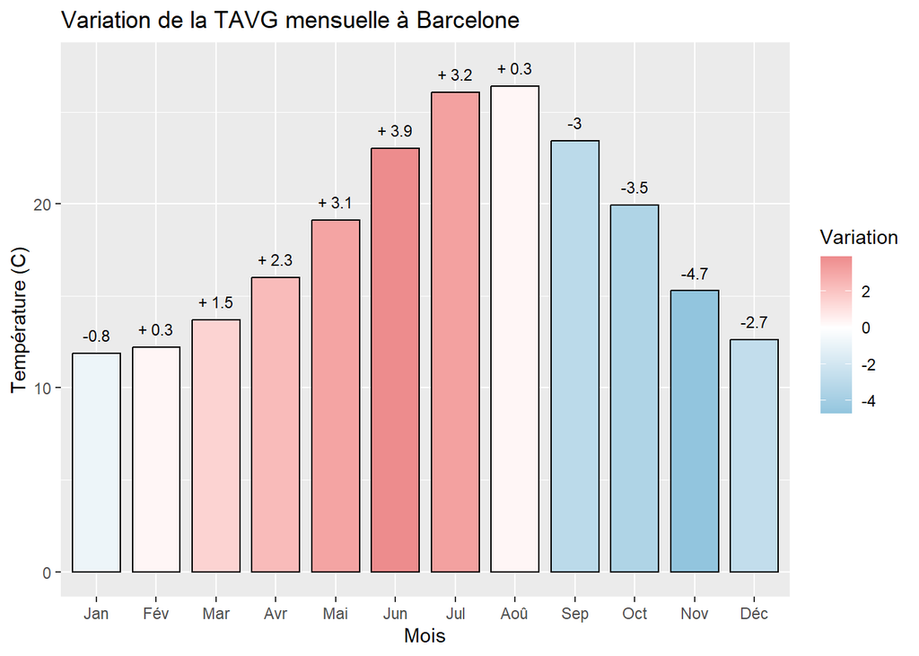

# **Comparaison entre 2008 et 2022 à Barcelone**

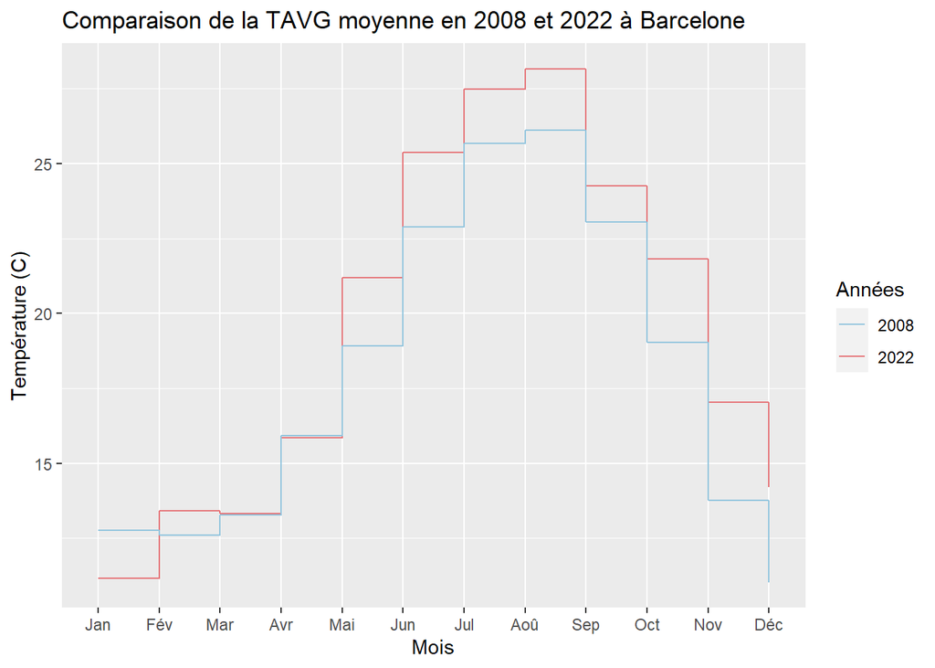

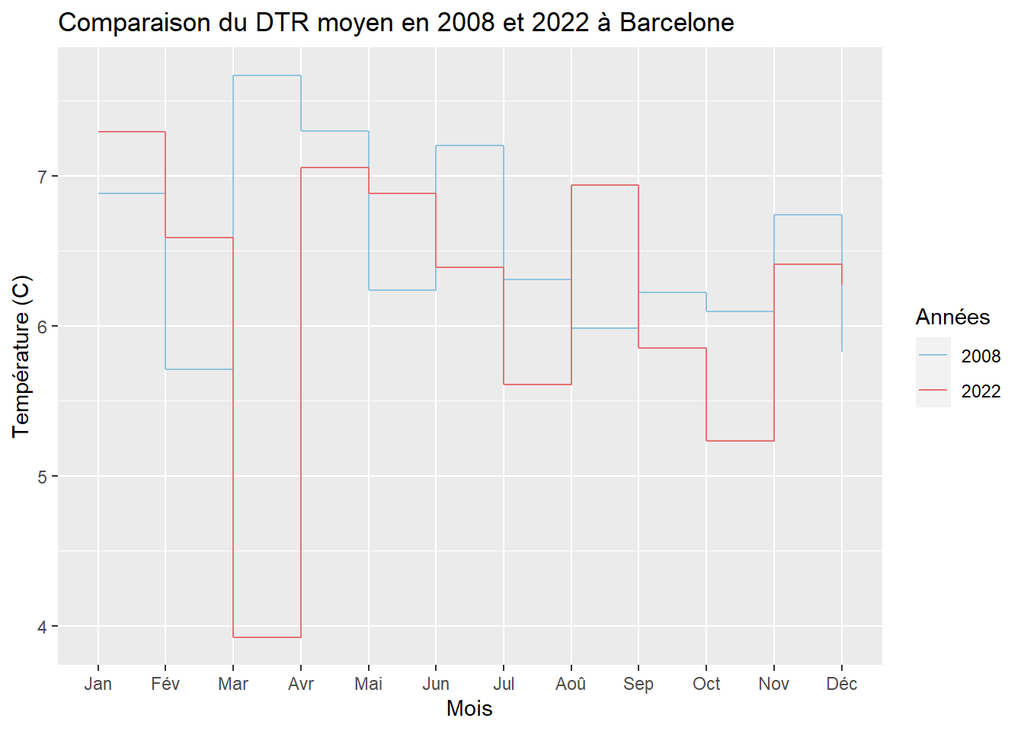

Ci-dessus une comparaison entre les températures moyennes mensuelles et une comparaison de l’étendue moyenne des températures par mois des années 2008 et 2022 à Barcelone. En rouge pour 2022 et en bleu pour 2008. Nous remarquons que globalement la température a augmenté entre ces deux périodes. En effet, la température moyenne a varié de +1.52°C entre 2008 et 2022 à Barcelone. De plus, il y avait globalement plus de variation de températures en 2008. Enfin, les variations se situent couramment entre 5.5 et 7.5°C.

# **Régression linéaire de la TAVG mensuelle à Barcelone**

```
##
## Call:
## lm(formula = TAVG ~ DTR + Mois, data = data_barca_mois)
##
## Residuals:
##     Min      1Q  Median      3Q     Max
## -8.2147 -0.6587 -0.0165  0.8587  3.7557
##
## Coefficients:
##             Estimate Std. Error t value Pr(>|t|)
## (Intercept)  26.7327     1.0505  25.447  < 2e-16 ***
## DTR          -0.1098     0.1671  -0.657    0.512
## MoisJan     -14.1645     0.4828 -29.341  < 2e-16 ***
## MoisFév     -13.8071     0.4854 -28.447  < 2e-16 ***
## MoisMar     -12.2933     0.4950 -24.833  < 2e-16 ***
## MoisAvr      -9.9925     0.4906 -20.367  < 2e-16 ***
## MoisMai      -6.8723     0.4958 -13.860  < 2e-16 ***
## MoisJun      -3.0117     0.4843  -6.218 3.65e-09 ***
## MoisAoû       0.3388     0.4853   0.698    0.486
## MoisSep      -2.6567     0.4853  -5.474 1.52e-07 ***
## MoisOct      -6.1420     0.4853 -12.655  < 2e-16 ***
## MoisNov     -10.7596     0.4896 -21.976  < 2e-16 ***
## MoisDéc     -13.4372     0.4867 -27.608  < 2e-16 ***
## ---
## Signif. codes:  0 '***' 0.001 '**' 0.01 '*' 0.05 '.' 0.1 ' ' 1
##
## Residual standard error: 1.329 on 173 degrees of freedom
## Multiple R-squared:  0.9423, Adjusted R-squared:  0.9383
## F-statistic: 235.6 on 12 and 173 DF,  p-value: < 2.2e-16
```

Nous avons choisi de mettre le mois de Juillet(Jul) en référence dans ce modèle de part sa température moyenne stable et élevée. Dans ce modèle, chaque mois est comparé au mois de référence (juillet), par exemple le coefficient pour janvier (MoisJan) est -14.16 comparé au mois de juillet. Cela indique une différence significative de la moyenne par rapport à juillet. Le modèle global permet d’expliquer environ 94% de la variable TAVG. Les variables MoisAoû et DTR ne sont pas significatives dans ce modèle en raison de leur p-value élevée. En revanche, toutes les autres variables le sont car elles ont des p-values proches de zéro. De plus la F-stat a une p-value très faible, par conséquent le modèle est significatif.

# **Comparaison entre Barcelone et Grenade selon la TAVG**

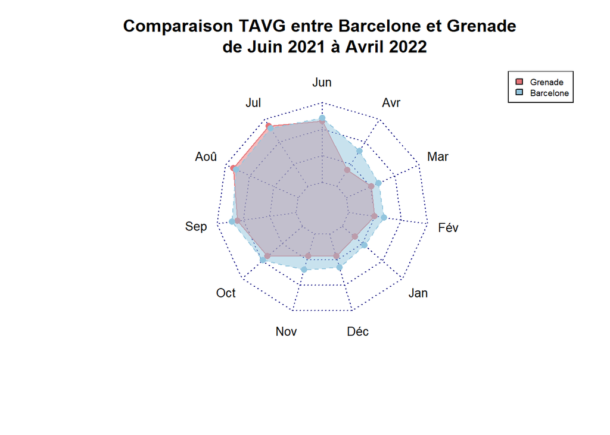

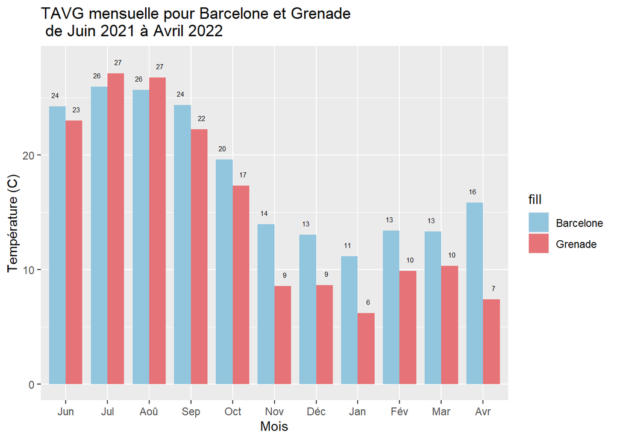

# **Conclusion de l’étude**